# Влияние техногенной взвеси

# Связь фитопланктона с техногенной взвесью

Второй способ оценки влияния взвеси на сообщества планктона основывается на визуальном (по спутниковым снимкам) определении области, где представлен шлейф взвешенных частиц. Этот шлейф читается в двух участках, где потенциально присутствует техногенная нагрузка: в районе терминала (далее *Terminal*) и в районе морского канала (далее *Channel*). Соответственно, в обеих участках можно выделить области, попадающие в зоны шлейфа (далее *In*) и области вне этой зоны (далее *Out*). Распределение концентрации взвешенных частиц в указанных зонах демонстрирует Рисунок 1. В пределах шлейфа концентрация частиц существенно выше в районе терминала и незначительно выше в районе канала.

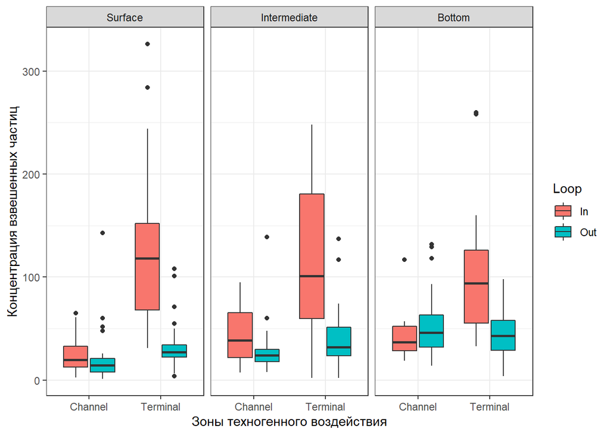

**Рисунок 1.** Значения концентрации взвешенных частиц в трех слоях воды в пределах визуально выявленного шлейфа взвеси (In) и за его пределами (Out) на двух участках активного техногенного воздействия

Обилие фитопланктона в указанных выделах демонстрирует Рисунок 2. Видно, что в пределах шлейфа обилие фитопланктона существенно ниже, чем за пределами шлейфа в районе терминала. Однако в районе морского канала существенных различивший не выявляется.

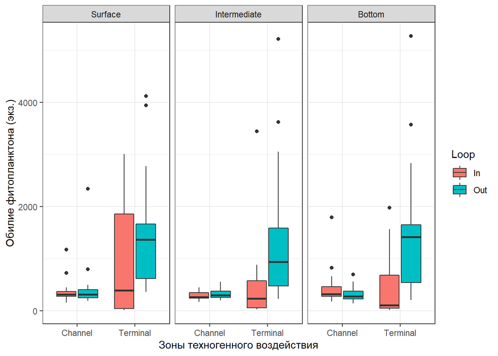

**Рисунок 2.** Суммарное обилие фитопланктона в трех слоях воды в пределах визуально выявленного шлейфа взвеси (In) и за его пределами (Out) на двух участках активного техногенного воздействия

Для более детальной оценки влияния взвешенных в воде частиц на обилие фитопланктона была подобрана модель, описывающая зависимость суммарного обилия фитопланктона (анализировали значение логарифма и вследствие выраженной нелинейности связи использовали аддитивные модели, GAM, Рисунок 3). В пределах шлейфа в районе терминала обилие фитопланктона было существенно ниже, чем в областях, находящихся за пределами шлейфа (линия регрессии для области шлейфа лежит ниже значения среднего для области, находящейся за пределами шлейфа). Столь сильного отклонения от среднего в районе канала не обнаружено.

Диапазон обилия между средними значениями для участков за пределами шлейфа взвеси (зона между красной и синей горизонтальными линиями на Рисунок 3) можно принять за приблизительную оценку нормального варьирования обилия фитопланктона. Тогда выход линий регрессии за пределы этого диапазона в зоне шлейфа можно трактовать как признак нарушения сообщества. Приблизительные границы нормы выходят за пределы доверительного интервала линии регрессии в области шлейфа при значениях концентрации более 200 мг/л. Приведенная величина может рассматриваться как приблизительная оценка границы воздействия, после которой начинается существенная деградация сообщества фитопланктона.

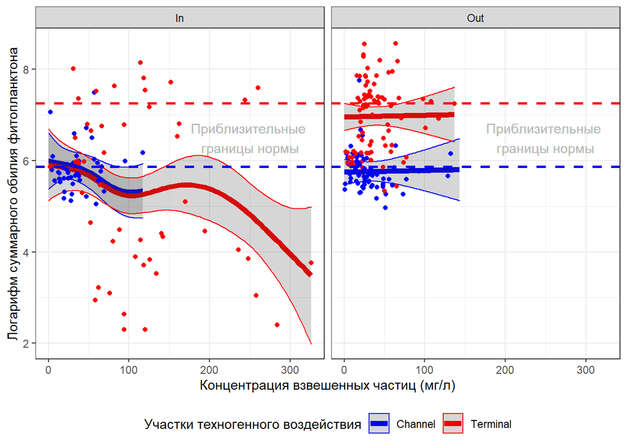

**Рисунок 3.** Зависимость суммарного обилия фитопланктона от концентрации взвешенных частиц в пределах визуального шлейфа взвеси (In) и за его пределами (Out) на двух участках активного техногенного воздействия. Горизонтальные пунктирные линии отражают среднее значение обилия фитопланктона в районе канала (синяя линия) и в районе терминала (красная линия).

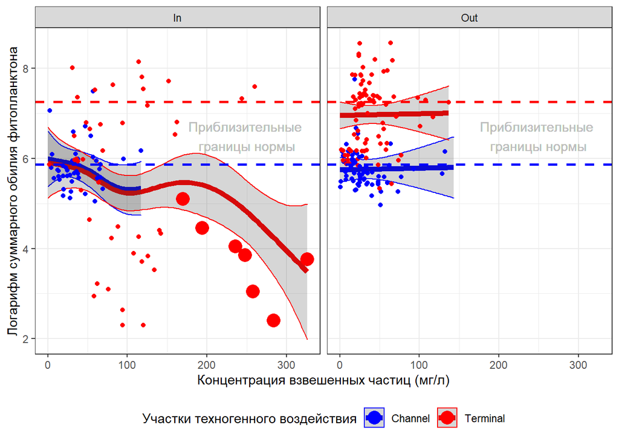

Большие точки - это станции O101, O102, O105, O107, O108, O109. Получилось на одну меньше, так как для одной станции (O109) приведено две точки - это два слоя воды (поверхностный и придонный).